# Homework 2

Yu-Jen Lin

#### b04b01036@ntu.edu.tw

#### ——————————————————————————————————————————————————–

## 1a. Generate 10000 random numbers from Gaussian distribution with mean=20 and variance =10, and plot the distribution.

I use “rnorm” function to generate the Gaussian distribution with mean=20 and variance =10. Then, I use “hist” to plot the histogram of this Gaussian distribution. In order to compare with the other distribution later, I add the mean of this distribution by a blue vertical line.

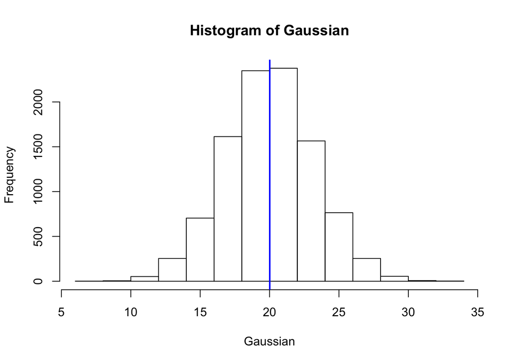

```r
Gaussian <- rnorm(n=10000, mean=20, sd=sqrt(10))
hist(Gaussian)
abline(v = mean(Gaussian), col = "blue", lwd = 2)
```

## 1b. Generate 10000 random numbers from Binomial distribution with p=0.5 and n=40, and plot the distribution.

First, I set a space for the following computations as “Binomial”. Secondly, I use “runif” to create a series number from 0 to 1. In my case, I regard all of these results as the probability of having a head when toss a coin. Thus, if the elements in RUNIF are larger than 0.5, that means I am more prone to get a head of coin. As a result, I count all the elements in RUNIF that >0.5 by doing the summation. Eventually, I get different numbers from each loop, which means the times I might have the head of coins when I toss 40 times. I add all these numbers into “Binomial” by “append” function.

```r
Binomial <- c()

for (i in c(1:10000) ){
  RUNIF <- runif(n=40, min=0, max=1)
  SUM <- sum(RUNIF>0.5)
  Binomial <- append(Binomial, SUM )
}
```

Then, I also use “hist” to plot the histogram of this Binomial distribution. In order to compare with the other distribution later, I add the mean of this distribution by a red vertical line.

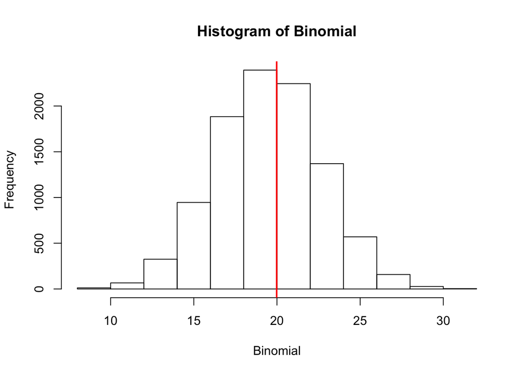

```r
hist(Binomial)
abline(v = mean(Binomial), col = "red", lwd = 2)
```

## Compare the distribution of 1a and 1b, what do you find?

(hint: you can use rand and randn in matlab. Or, “runif” and “rnorm” in R) These two distributions are quite the same because binomial distribution would approached Gaussian distributions when the sample size is large.

# compare the hist

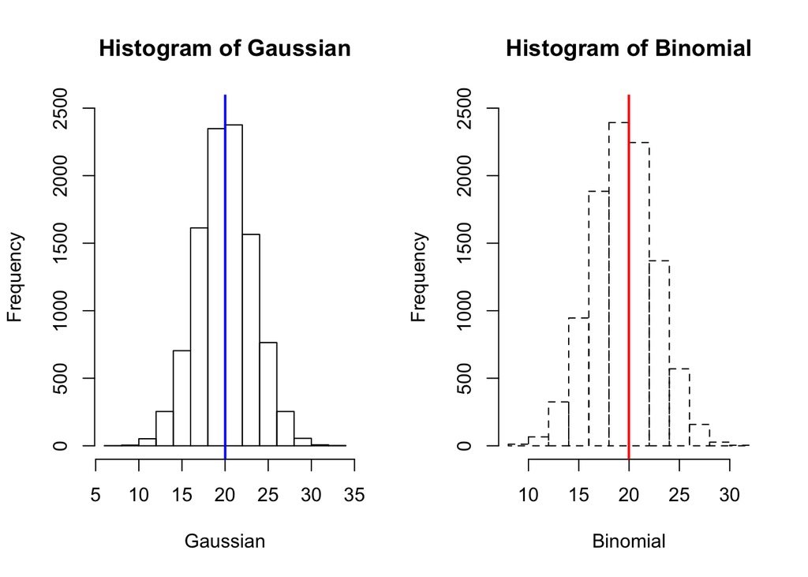

```r
par(mfrow = c(1,2))
hist(Gaussian, ylim=c(0, 2500))
abline(v = mean(Gaussian), col = "blue", lwd = 2)
hist(Binomial, lty=2, ylim=c(0, 2500))
abline(v = mean(Binomial), col = "red", lwd = 2)
```

# overlay the hist

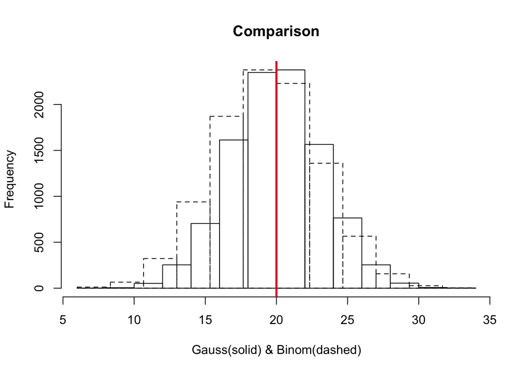

```r
hist(Gaussian, xlab = "Gauss(solid) & Binom(dashed)", main = "Comparison")
abline(v = mean(Gaussian), col = "blue", lwd = 2)
par(new = TRUE) #New plot
hist(Binomial, lty=2, axes = FALSE, xlab = "", ylab = "", main ="")
abline(v = mean(Binomial), col = "red", lwd = 2)
```

# 2. Make a program that can select our candidates for presentation next week. This program should select randomly but avoid selecting the numbers that had been selected before.

# (hint: uniform distribution, loop, and if statements.)

# Read roster.csv into R

```r
roster <- read.csv(file="~/R/roster.csv", header=TRUE)
```

# select our candidates

candidate <- c() presentation <- c()

for (i in c(1:10000)){ candidate <- round(runif(n=1, min=1, max=23)) if (canddidate %in% presentation){ } else { presentation <- append(presentation,candidate) } }